# Advanced R graphics

# Graphics for Communication with ggplot2

To help others quickly build up a good mental model of the data, you will need to invest considerable effort in making your plots as self-explanatory as possible.

### Label

- The easiest place to start when turning an exploratory graphic into an expository graphic is with good labels.

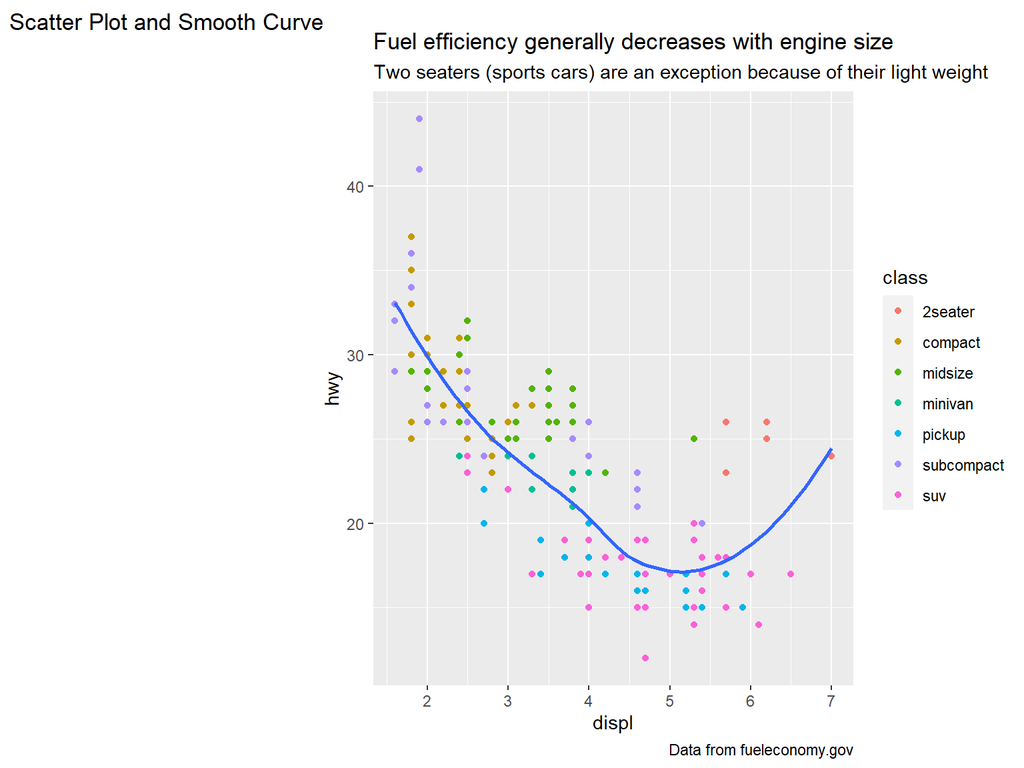

```r
ggplot(mpg, aes(displ, hwy)) +
  geom_point(aes(color = class)) +
  geom_smooth(se = FALSE) +
  labs(
    tag = "Scatter Plot and Smooth Curve",
    title = "Fuel efficiency generally decreases with engine size",
    subtitle = "Two seaters (sports cars) are an exception because of their light weight",
    caption = "Data from fueleconomy.gov"
  )
```

# mathematical equations

- Use mathematical equations instead of text strings.

```
ggplot(mpg, aes(displ, hwy)) +
geom_point(aes(color = class)) +
geom_smooth(se = FALSE) +
labs(
x = "Engine displacement (L)",
y = "Highway fuel economy (mpg)",
colour = "Car type"
)

df <- tibble(
x = runif(10),
y = runif(10)
)
ggplot(df, aes(x, y)) +
geom_point() +
labs(
x = quote(sum(x[i] ^ 2, i == 1, n)),
y = quote(alpha + beta + frac(delta, theta))
)
```

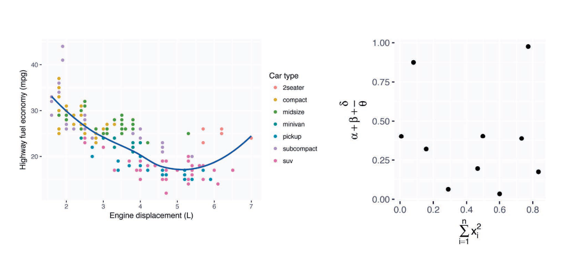

# Scale

Adjust the scales is another way to make a plot better for communication.

Normally, ggplot2 adds scales automatically. For example:

```
ggplot(mpg, aes(displ, hwy)) +
geom_point(aes(color = class))
```

ggplot2 automatically adds default scales behind the scenes:

```
ggplot(mpg, aes(displ, hwy)) +
geom_point(aes(color = class)) +
scale_x_continuous() +
scale_y_continuous() +
scale_color_discrete()
```

# Axis Ticks and Legend Keys

There are two primary arguments that affect the appearance of the ticks on the axes and the keys on the legend: breaks and labels.

Breaks controls the position of the ticks, or the values associatedwith the keys. Labels controls the text label associated with each tick/key.

```
#Breaks
ggplot(mpg, aes(displ, hwy)) +
geom_point() +
scale_y_continuous(breaks = seq(15, 40, by = 5))

#labels
ggplot(mpg, aes(displ, hwy)) +
geom_point() +
scale_x_continuous(labels = NULL) +
scale_y_continuous(labels = NULL)
```

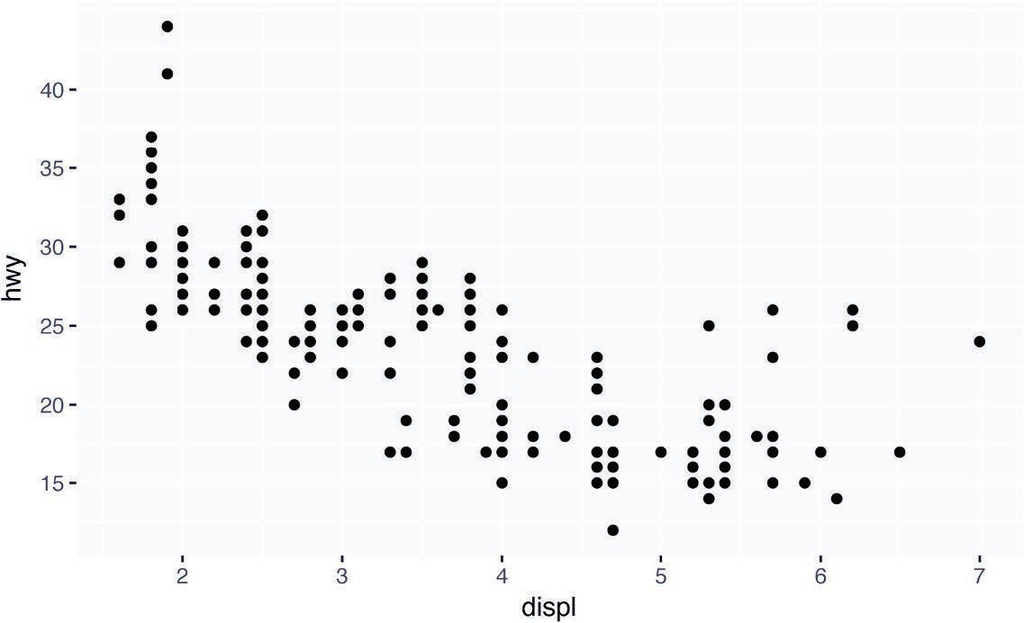

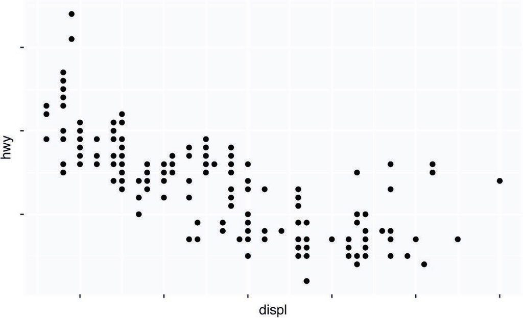

# Replacing a Scale

Instead of just tweaking the details a little, you can replace the scale altogether.

```
#初始图像
ggplot(diamonds, aes(carat, price)) +
  geom_bin2d()
ggplot(diamonds, aes(log10(carat), log10(price))) +
  geom_bin2d()


#使用标度进行对数转换
ggplot(diamonds, aes(carat, price)) +
  geom_bin2d() +
  scale_x_log10() +
  scale_y_log10()
```

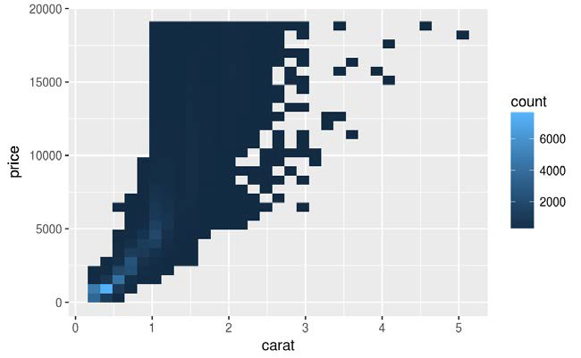

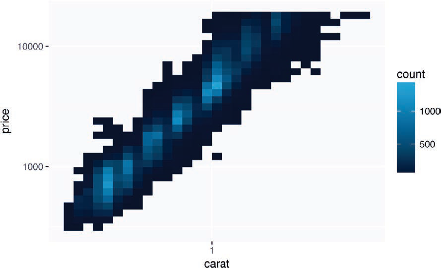

# scale_color_brewer

```
ggplot(mpg, aes(displ, hwy)) +
geom_point(aes(color = drv))

ggplot(mpg, aes(displ, hwy)) +
geom_point(aes(color = drv)) +
scale_color_brewer(palette = "Set1")
```

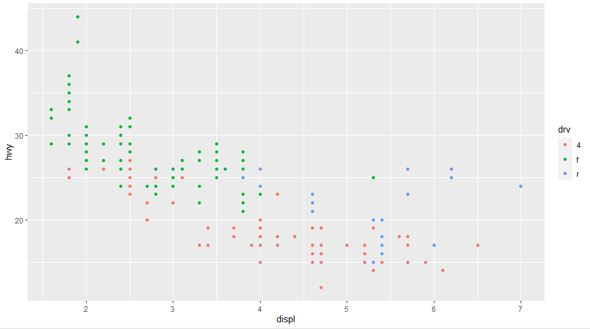

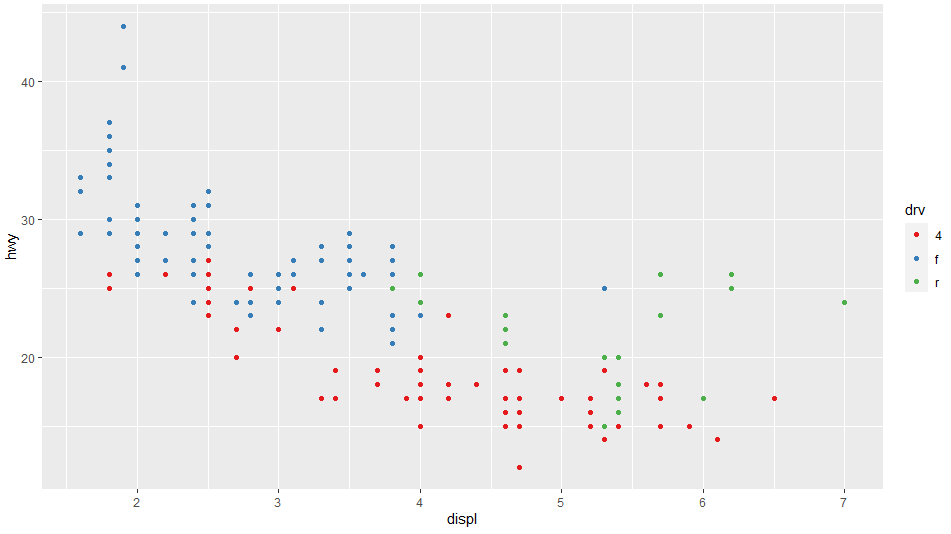

Other palettes

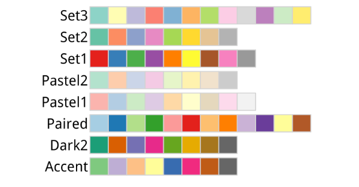

# Theme

Finally, we can customize the nondata elements of your plot with a theme.

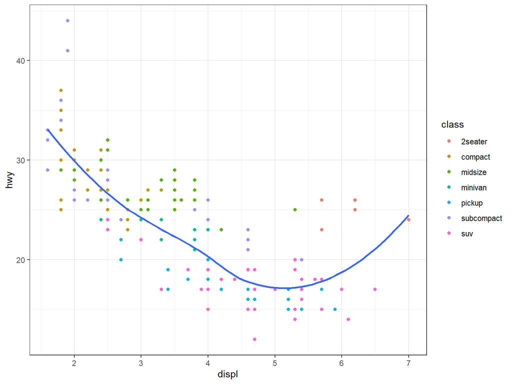

```r
ggplot(mpg, aes(displ, hwy)) +
geom_point(aes(color = class)) +
geom_smooth(se = FALSE) +
theme_bw()
```

# Eight themes

ggplot2 includes eight themes by default. Many more are included in add-on packages like ggthemes, by Jeffrey Arnold.

theme(legend.position) can be used to select the legend position. theme_set() can change the theme (color scheme, font, etc.) of subsequent ggplot2 drawings. Such as theme_set (theme_bw ()), theme_set (theme_dark ()) and so on. For a single drawing, you can directly connect these theme functions such as theme_gray() with a plus sign. Topics include theme_gray() (default theme), theme_minimal(), theme_classic(), and so on.

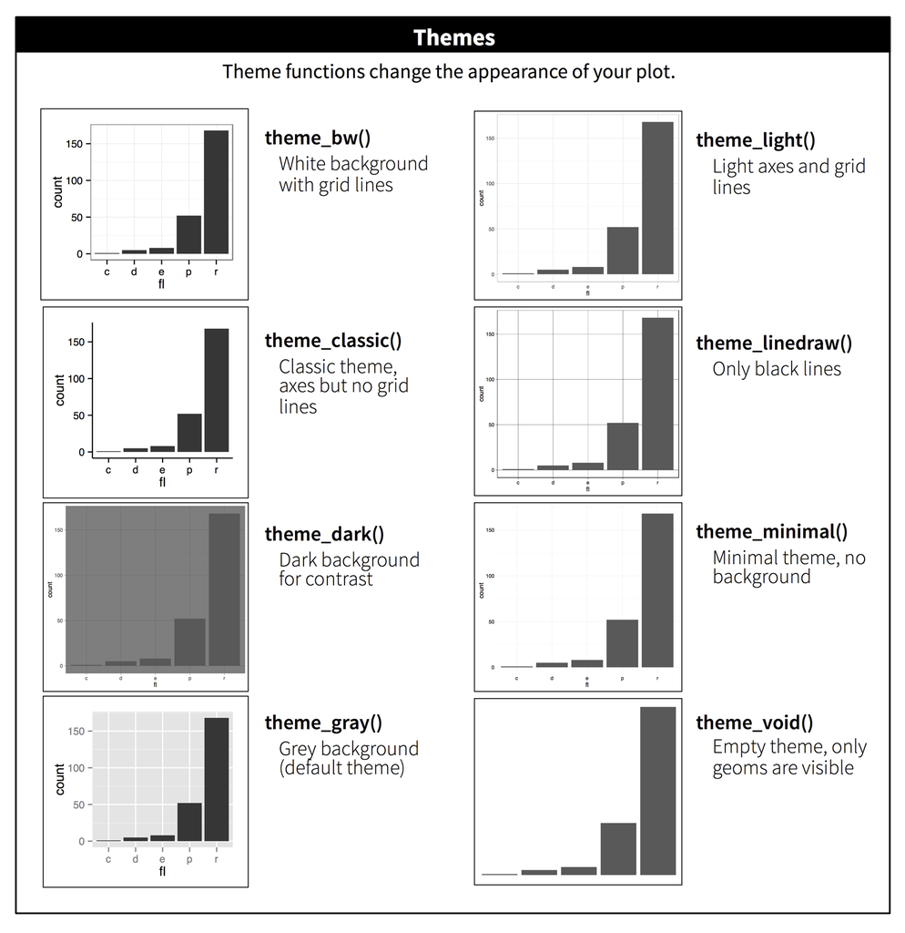

# Legend Layout

Legend is automatically generated while using color or shape to classify variables.

Use a method like guides(color = FALSE) to undo the legend for the specified dimension.

Changing the position of the legend with legend.position of theme( ), such as using theme(legend.position = “top”) to place the legendon top, the default if placed on the right. “none”, “left”, “right”, “bottom” are also can be taken.

```
base <- ggplot(mpg, aes(displ, hwy)) +
geom_point(aes(color = class))
base + theme(legend.position = "left")
base + theme(legend.position = "top")
base + theme(legend.position = "bottom")
base + theme(legend.position = "right")
```

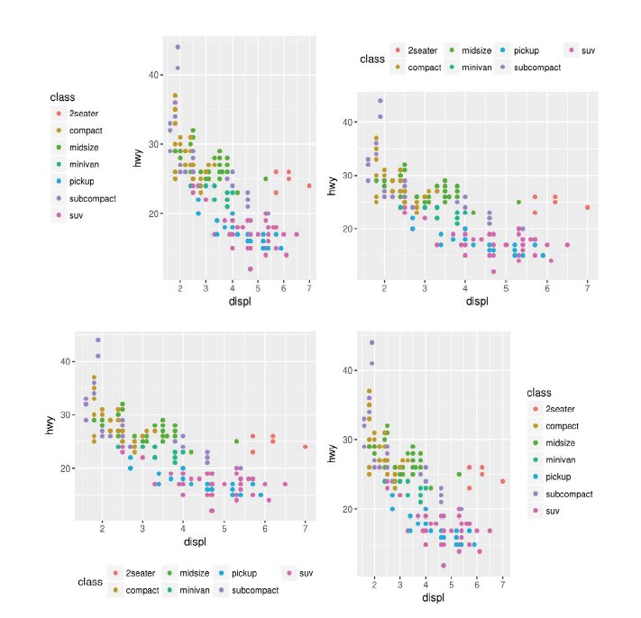

# Save plots

ggsave is a convenient function for saving a plot. It defaults to saving the last plot that you displayed, using the size of the current graphics device. It also guesses the type of graphics device from the extension.

```
ggplot(mpg, aes(displ, hwy)) + geom_point()
ggsave("my-plot.pdf")
```

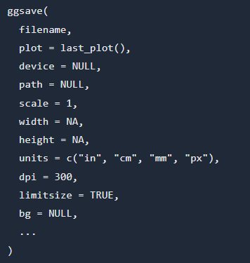

# Learning More

[《R Graphics Cookbook, 2nd edition》](https://r-graphics.org/)

[《ggplot2: Elegant Graphics for Data Analysis》](https://ggplot2-book.org/introduction.html)